# Medidas de tendencia central

[Cesar Gerardo Hernández Vargas](https://cghv94.github.io)

Estadística 2022-2, [Facultad de economía](http://www.economia.unam.mx/)

2/3/2022

### 1. ¿Qué son las medidas de tendencia central? 🤔

Para este ejemplo, primero generaremos una serie de **100** números aleatorios entre `1` y `20` mediante la función `sample`. El argumento `TRUE` nos permitirá generar una muestra con remplazo:

```r
numeros <- sample(1:20, 100, TRUE)
numeros
```

```
##   [1] 17 16  1 11  6  5 19  7  7 16  3  9 15 14  4 11  5  2 13 13 11 15  4 19  2
##  [26]  1 20 10 17 14 14  4 17  3 13 19 11 11 10  8 11 17  9 13 13 11 16 19  4 12
##  [51]  1 15 13 20 10  9 13 13 20 20  4 10 19 12 16  9 14  8 17 13 17  7 19 12  7
##  [76]  8 11  8  5  3 20  3  9 16  1  2  2  7  1 16 14 19  6  4 12  9 12 13 16  1
```

### 2. Mediana 📍

Para obtener la **mediana**, ordenamos los `numeros` de menor a mayor con la función `sort`, **el número que esté en medio de la muestra será la mediana**:

```r
numeros <- sort(numeros)
# La función length nos permitirá saber la cantitad de elementos del objeto "numeros"
mitad <- length(numeros)/2
mediana <- numeros[mitad]
mediana
```

```
## [1] 11
```

### 3. Media 🧮

$$Media ={\frac {1}{n}}\sum _{i=1}^{n}a_{i}={\frac {a_{1}+a_{2}+\cdots +a_{n}}{n}}$$

Si usamos R, podemos obtener la media de una muestra si utlilizamos la función **mean**:

```r
media <- mean(numeros)
media
```

```
## [1] 10.78
```

### 4. Moda 📊

Podemos saber cuál es la **frecuencia** (número de veces que aparece un elemento en una muestra) de cada número si dibujamos un **histograma** con la función `hist`, **aquél elemento con mayor frecuencia será la moda**:

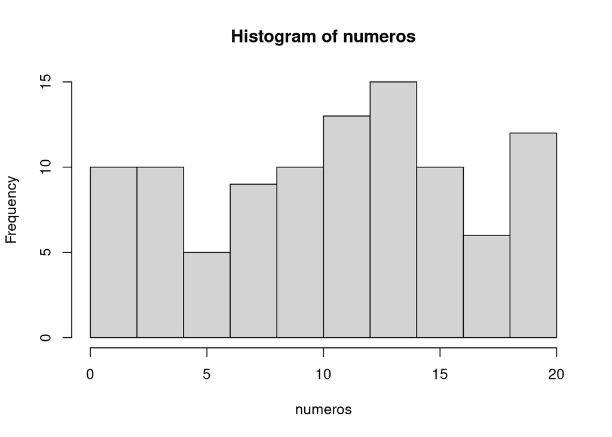

```r
hist(numeros)
```

También podemos obtener la **moda** si generamos una **tabla de frecuencias** con la función `table` y la función `data.frame`:

```r
tabla.frecuencias <- data.frame(table(numeros))
tabla.frecuencias
```

```
##    numeros Freq
## 1        1    6
## 2        2    4
## 3        3    4
## 4        4    6
## 5        5    3
## 6        6    2
## 7        7    5
## 8        8    4
## 9        9    6
## 10      10    4
## 11      11    8
## 12      12    5
## 13      13   10
## 14      14    5
## 15      15    3
## 16      16    7
## 17      17    6
## 18      19    7
## 19      20    5
```

### 5. Ejercicio 👩‍💻👨‍💻✍

Aplica lo que aprendiste, obten la **mediana**, **media** y **moda** de la siguiente muestra de números:

```r
secuencia <- seq(1, 10, 0.1)
muestra <- sample(secuencia, 100, TRUE)
muestra
```

```
##   [1]  9.5  2.9  6.8  3.1  3.5  2.9  7.8  9.8  1.2  5.4  2.4  3.7  3.6  1.9  7.7
##  [16]  3.6  3.1  9.6  8.8  4.4  5.0  1.3  1.3  4.0  9.4  7.6  8.7  9.2  6.2  8.3
##  [31]  9.8  2.5  4.9  5.0  1.6  1.9  3.1  9.9  7.0  3.1  2.3  3.8  4.4  9.3  7.8
##  [46] 10.0  3.7  9.8  2.4  9.9  5.5  7.0  4.6  4.3  5.9  1.8  4.5  5.6  8.3  5.6
##  [61]  6.2  7.1  5.9 10.0  1.3  9.8  9.1  8.5  5.8  8.1  7.9  4.8  6.2  2.2  4.4
##  [76]  9.1  9.6  9.8  2.6  3.9  6.4  3.1  4.9  6.4  5.2  6.7  8.4  3.6  6.8  8.8
##  [91]  3.3  4.3  5.1  5.9  4.2  2.1  9.8  6.0  1.0  6.2
```

##### Mediana

```r
# Aquí el cálculo de la mediana
```

##### Media

```r
# Aquí el cálculo de la media
```

##### Moda

```r
# Aquí el cálculo de la moda
```